# Final assignment

## Predicting False Alarms in London Fire Brigade Incidents

**An exploratory analysis to identify factors that contribute to false alarm callouts**

#### MSIN0143: Programming for Business Analytics Team Assignment 25/26

**group name:** Group2_MSIN001

**Team Members:** Nesma Elyan-25183441/ Ines El Mourabit- 25249325 / Aljoharah Alrajhi- 25162483 / Hemakshi Chandwani- 25209743 /Sumayya Uddin- 25158782

#### Word count: 1982 words (excluding code and references)

```python
import json

def count_words_in_markdown(ipynb_path):
    with open(ipynb_path, 'r', encoding='utf-8') as f:
        data = json.load(f)

    word_count = 0
    for cell in data['cells']:
        if cell['cell_type'] == 'markdown':
            text = ' '.join(cell['source'])
            words = text.split()
            word_count += len(words)
    return word_count
```

```python
file_path = 'Final assignment.ipynb'
count_words_in_markdown(file_path)
```

```
1982
```

## 1. Introduction

The London Fire Brigade (LFB) responds to thousands of incidents each year, many of which turn out to be false alarms. These false callouts divert crews from genuine emergencies and cost the service millions annually. Around 40% of all LFB callouts are false alarms, often triggered by automatic systems in commercial and residential buildings wasting resources and potentially delaying responses to real incidents (Fire Bridge, n.d.).

**Research Question**: What factors drive false alarm callouts, and can they be predicted using temporal, geographic, and property-related characteristics?

**Business Impact**: Effective prediction would allow the LFB to target maintenance issues, educate property owners, and allocate resources more efficiently.

**Dataset Overview**: The analysis uses 236,763 incident records from 2024 onwards, covering variables such as incident type, time, location, property details, and estimated costs, sourced from the London Datastore.

**Approach**: We clean and explore the dataset, engineer relevant features, and build Decision Tree and Random Forest models to identify key predictors and inform data-driven recommendations.

## Data Preparation

In this section, we load the London Fire Brigade incident data, explore its structure, and clean it for analysis.

### 2.1 Data Loading

```python
# Import libraries
import pandas as pd
import numpy as np
import matplotlib.pyplot as plt
import seaborn as sns

# Set display options for better readability
pd.set_option('display.max_columns', None)
plt.style.use('seaborn-v0_8-darkgrid')

# Load the CSV dataset
LFB_data = pd.read_csv('LFB Incident data from 2024 onwards.csv')

# Display and view the first few records for initial inspection
print(f"Dataset loaded: {len(LFB_data):,} rows, {len(LFB_data.columns)} columns")
print("\nFirst 5 rows:")
print(LFB_data.head())
```

```
Dataset loaded: 236,763 rows, 39 columns

First 5 rows:
    IncidentNumber DateOfCall  CalYear TimeOfCall  HourOfCall  \
0  000002-01012024  01-Jan-24     2024   00:00:43           0
1  000003-01012024  01-Jan-24     2024   00:01:11           0
2  000007-01012024  01-Jan-24     2024   00:04:21           0
3  000010-01012024  01-Jan-24     2024   00:05:40           0
4  000011-01012024  01-Jan-24     2024   00:06:32           0

     IncidentGroup        StopCodeDescription           SpecialServiceType  \
0  Special Service            Special Service                  Advice Only
1  Special Service            Special Service  No action (not false alarm)
2      False Alarm  False alarm - Good intent                          NaN
3  Special Service            Special Service                 Lift Release
4  Special Service            Special Service         Effecting entry/exit

  PropertyCategory                                       PropertyType  \
0         Dwelling  Unlicensed House in Multiple Occupation - Up t...
1         Dwelling  Purpose Built Flats/Maisonettes - 10 or more s...
2          Outdoor                                      Loose refuse
3         Dwelling  Purpose Built Flats/Maisonettes - 4 to 9 storeys
4         Dwelling  Purpose Built Flats/Maisonettes - 10 or more s...

                   AddressQualifier Postcode_full Postcode_district  \
0         Correct incident location           NaN               E11
1              Within same building           NaN                E2
2  On land associated with building      SE17 3NA              SE17
3         Correct incident location           NaN                W3
4         Correct incident location           NaN               SE3

           UPRN      USRN IncGeo_BoroughCode IncGeo_BoroughName  \
0  0.000000e+00  22822050          E09000031     WALTHAM FOREST
1  0.000000e+00  20901068          E09000012            HACKNEY
2  1.002554e+10  22501860          E09000028          SOUTHWARK
3  0.000000e+00  20601340          E09000009             EALING
4  0.000000e+00  20802154          E09000011          GREENWICH

       ProperCase IncGeo_WardCode                IncGeo_WardName  \
0  Waltham Forest       E05013882                      CANN HALL
```

[output cut: 31 more lines]

```
4                                NaN                                    NaN

   NumStationsWithPumpsAttending  NumPumpsAttending  PumpCount  \
0                            2.0                2.0          2
1                            1.0                1.0          1
2                            1.0                1.0          1
3                            1.0                1.0          1
4                            1.0                1.0          1

   PumpMinutesRounded  Notional Cost (£)  NumCalls
0                  60                388       1.0
1                  60                388       1.0
2                  60                388       1.0
3                  60                388       1.0
4                  60                388       2.0
```

### 2.2 Data Exploration

Before cleaning, we need to understand the dataset structure, identify data quality issues, and check for missing values.

```python
# Check dataset dimensions
print("Dataset Dimensions:")
print(f"Rows: {LFB_data.shape[0]:,}")
print(f"Columns: {LFB_data.shape[1]}")

# Check data types
print("\nData Types:")
print(LFB_data.dtypes.value_counts())

# Check missing values
print("\nMissing Values:")
missing = LFB_data.isnull().sum()
missing_pct = (missing / len(LFB_data) * 100).round(2)
missing_df = pd.DataFrame({'Missing_Count': missing, 'Percentage': missing_pct})
print(missing_df[missing_df['Missing_Count'] > 0].sort_values('Missing_Count', ascending=False))

# Check for duplicates
duplicates = LFB_data.duplicated().sum()
print(f"\nDuplicate rows: {duplicates:,}")
```

```
Dataset Dimensions:
Rows: 236,763
Columns: 39

Data Types:
object     21
float64    10
int64       8
Name: count, dtype: int64

Missing Values:
                                        Missing_Count  Percentage
SecondPumpArriving_AttendanceTime              150083       63.39
SecondPumpArriving_DeployedFromStation         150083       63.39
Latitude                                       144593       61.07
Postcode_full                                  144593       61.07
Northing_m                                     144593       61.07
Longitude                                      144593       61.07
Easting_m                                      144593       61.07
SpecialServiceType                             141850       59.91
FirstPumpArriving_DeployedFromStation           12040        5.09
FirstPumpArriving_AttendanceTime                12040        5.09
NumPumpsAttending                                2539        1.07
NumStationsWithPumpsAttending                    2539        1.07
IncGeo_WardName                                   528        0.22
IncGeo_WardNameNew                                528        0.22
IncGeo_WardCode                                   528        0.22
NumCalls                                            9        0.00
IncidentGroup                                       8        0.00
PropertyCategory                                    6        0.00
PropertyType                                        6        0.00
AddressQualifier                                    1        0.00

Duplicate rows: 0
```

The dataset initially contained 236,763 rows with several columns showing high missing values. Since many of these variables were irrelevant to the analysis, they were removed, while missing values in key fields like IncidentGroup, PropertyCategory, and PropertyType were small enough to be dropped without affecting data validity.

### 2.3 Data Cleaning

We now clean the dataset by choosing the relevant values, converting data types, and removing null values.

```python
# Store original size
original_rows = len(LFB_data)
print(f"Original dataset: {original_rows:,} rows\n")

# Select relevant columns for analysis
relevant_cols = [
    'IncidentNumber', 'DateOfCall', 'CalYear', 'TimeOfCall', 'HourOfCall',
    'IncidentGroup', 'StopCodeDescription', 'SpecialServiceType',
    'PropertyCategory', 'PropertyType', 'IncGeo_BoroughName', 'FRS', 'Notional Cost (£)'
]

LFB_data = LFB_data[relevant_cols].copy()
print(f"Step 1 - Selected {len(relevant_cols)} relevant columns")

# Drop rows with NULL values.
before = len(LFB_data)
critical_cols = ['IncidentNumber', 'DateOfCall', 'TimeOfCall', 'HourOfCall',
                 'IncidentGroup', 'StopCodeDescription', 'PropertyCategory', 'IncGeo_BoroughName']
LFB_data = LFB_data.dropna(subset=critical_cols)
print(f"Step 2 - Dropped {before - len(LFB_data):,} rows with missing critical values")


# Convert data types
LFB_data['HourOfCall'] = LFB_data['HourOfCall'].astype(int)
LFB_data['CalYear'] = LFB_data['CalYear'].astype(int)
LFB_data['Notional Cost (£)'] = pd.to_numeric(LFB_data['Notional Cost (£)'], errors='coerce')
print(f"Step 3 - Converted HourOfCall, CalYear, and Notional Cost to numeric")


# Reset index
LFB_data = LFB_data.reset_index(drop=True)
```

[output not shown]

To ensure the dataset was clean and aligned with our study objective, we reduced the original 39 columns to 13 relevant variables and dropped rows containing critical missing values. We then converted key fields such as hour of call, year, and notional cost into numeric formats to prepare the data for analysis.

## 3. Exploratory Data Analysis

Now that our data is clean, we explore patterns and relationships to understand the factors that drive false alarms in London Fire Brigade incidents.

### 3.1 False Alarm Distribution

```
Target Variable Distribution:
==================================================

False Alarms (1):      109,932 ( 46.4%)
Real Emergencies (0):  126,823 ( 53.6%)
```

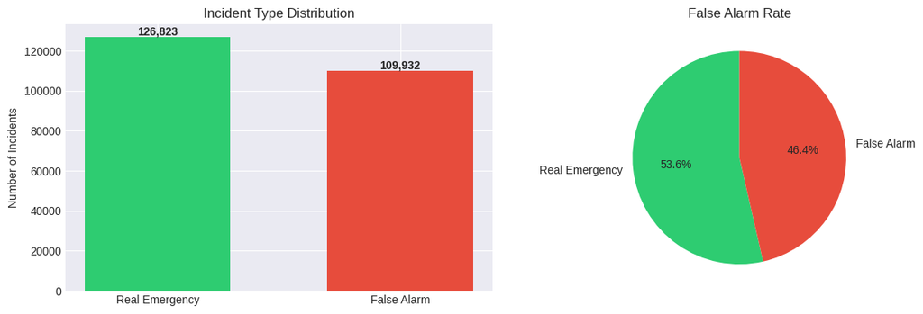

```
 False alarm rate: 46.4%
```

```python
# Create binary variable where 1 = False Alarm and 0 = Real Emergency
LFB_data['IsFalseAlarm'] = (LFB_data['IncidentGroup'] == 'False Alarm').astype(int)

# Check distribution
print("Target Variable Distribution:")
print("="*50)
fa_counts = LFB_data['IsFalseAlarm'].value_counts()
print(f"\nFalse Alarms (1):     {fa_counts[1]:>8,} ({fa_counts[1]/len(LFB_data)*100:5.1f}%)")
print(f"Real Emergencies (0): {fa_counts[0]:>8,} ({fa_counts[0]/len(LFB_data)*100:5.1f}%)")

# Visualize distribution
fig, (ax1, ax2) = plt.subplots(1, 2, figsize=(12, 4))

# Bar chart
colors = ['#2ecc71', '#e74c3c']
ax1.bar(['Real Emergency', 'False Alarm'], fa_counts.values, color=colors, width=0.6)
ax1.set_ylabel('Number of Incidents')
ax1.set_title('Incident Type Distribution')

# Add text labels above bars
for i, v in enumerate(fa_counts.values):
    ax1.text(i, v + 1000, f'{v:,}', ha='center', fontweight='bold')

# Pie chart
ax2.pie(fa_counts.values, labels=['Real Emergency', 'False Alarm'],
        colors=colors, autopct='%1.1f%%', startangle=90)
ax2.set_title('False Alarm Rate')

# Display both charts
plt.tight_layout()
plt.show()

# Print overall false alarm percentage
print(f"\n False alarm rate: {fa_counts[1]/len(LFB_data)*100:.1f}%")
```

False alarms represent 46.4% of all LFB incident responses, significantly higher than the national average of 40% (Watts, 2022). This indicates substantial wasted resources that could be redirected to genuine emergencies, and potentially reduce response time.

### 3.2 Time-related Patterns

We investigate whether false alarms follow predictable time-based patterns.

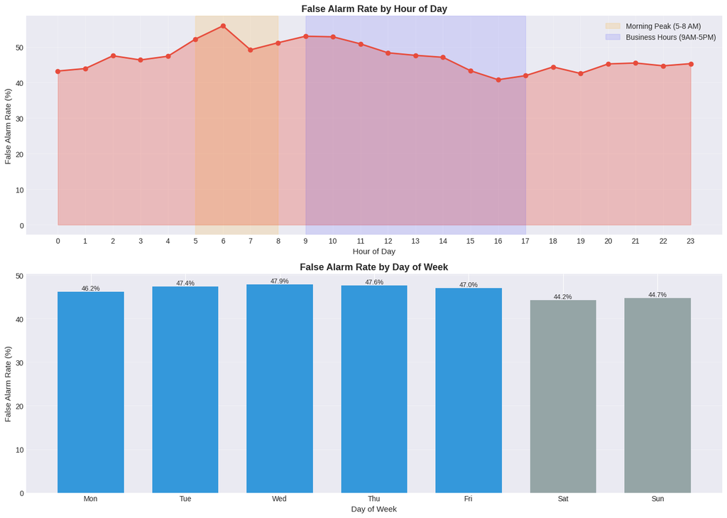

```
Key Temporal Insights:
======================================================================
Peak false alarm hour:     06:00 (55.9%)
Morning peak FA rate (5-8AM): 52.2%
Business hours FA rate:       47.6%
Non-business hours FA rate:   45.6%

Weekday FA rate:              47.2%
Weekend FA rate:              44.5%
```

```python
# Temporal analysis of False Alarms
# Make sure DateOfCall is in datetime format
LFB_data['DateOfCall'] = pd.to_datetime(LFB_data['DateOfCall'], errors='coerce')

# Create simple time features
LFB_data['DayOfWeek'] = LFB_data['DateOfCall'].dt.dayofweek    # 0 = Monday, 6 = Sunday
LFB_data['Month'] = LFB_data['DateOfCall'].dt.month

# Compute false alarm rate and total incidents by hour of call
hourly_fa = LFB_data.groupby('HourOfCall')['IsFalseAlarm'].agg(['mean', 'count']).reset_index()
hourly_fa.columns = ['Hour', 'FalseAlarmRate', 'TotalIncidents']

# Compute false alarm rate and total incidents by day of week
daily_fa = LFB_data.groupby('DayOfWeek')['IsFalseAlarm'].agg(['mean', 'count']).reset_index()
daily_fa.columns = ['DayOfWeek', 'FalseAlarmRate', 'TotalIncidents']

# Visualizing temporal False Alarm patterns
fig, (ax1, ax2) = plt.subplots(2, 1, figsize=(14, 10))

# Hourly pattern
ax1.plot(hourly_fa['Hour'], hourly_fa['FalseAlarmRate']*100,
         marker='o', linewidth=2, markersize=6, color='#e74c3c')
ax1.fill_between(hourly_fa['Hour'], hourly_fa['FalseAlarmRate']*100, alpha=0.3, color='#e74c3c')
ax1.set_xlabel('Hour of Day', fontsize=11)
ax1.set_ylabel('False Alarm Rate (%)', fontsize=11)
ax1.set_title('False Alarm Rate by Hour of Day', fontsize=13, fontweight='bold')
ax1.grid(alpha=0.3)
ax1.set_xticks(range(0, 24))

# Add "Morning Peak" shading (5-8 AM where peak occurs)
ax1.axvspan(5, 8, alpha=0.15, color='orange', label='Morning Peak (5-8 AM)')
# Add business hours shading
ax1.axvspan(9, 17, alpha=0.1, color='blue', label='Business Hours (9AM-5PM)')
ax1.legend()

# Plot false alarm rate by day of week
day_labels = ['Mon', 'Tue', 'Wed', 'Thu', 'Fri', 'Sat', 'Sun']
colors_days = ['#3498db' if i < 5 else '#95a5a6' for i in range(7)]
bars = ax2.bar(range(7), daily_fa['FalseAlarmRate']*100, color=colors_days, width=0.7)
ax2.set_xlabel('Day of Week', fontsize=11)
ax2.set_ylabel('False Alarm Rate (%)', fontsize=11)
ax2.set_title('False Alarm Rate by Day of Week', fontsize=13, fontweight='bold')
ax2.set_xticks(range(7))
ax2.set_xticklabels(day_labels)
ax2.grid(axis='y', alpha=0.3)

# Add percentage labels above each bar
for i, bar in enumerate(bars):
    height = bar.get_height()
    ax2.text(bar.get_x() + bar.get_width()/2., height,
             f'{height:.1f}%', ha='center', va='bottom', fontsize=9)

plt.tight_layout()
plt.show()

# Summarising Key Insights
print("Key Temporal Insights:")
print("="*70)

# Identify hour with highest false alarm rate
peak_hour = hourly_fa.loc[hourly_fa['FalseAlarmRate'].idxmax()]
print(f"Peak false alarm hour:     {int(peak_hour['Hour']):02d}:00 ({peak_hour['FalseAlarmRate']*100:.1f}%)")

# Compare false alarm rates across specific time windows
morning_peak = LFB_data[(LFB_data['HourOfCall'] >= 5) & (LFB_data['HourOfCall'] < 8)]['IsFalseAlarm'].mean()
business_hours_fa = LFB_data[(LFB_data['HourOfCall'] >= 9) & (LFB_data['HourOfCall'] < 17)]['IsFalseAlarm'].mean()
non_business_fa = LFB_data[(LFB_data['HourOfCall'] < 9) | (LFB_data['HourOfCall'] >= 17)]['IsFalseAlarm'].mean()

print(f"Morning peak FA rate (5-8AM): {morning_peak*100:.1f}%")
print(f"Business hours FA rate:       {business_hours_fa*100:.1f}%")
print(f"Non-business hours FA rate:   {non_business_fa*100:.1f}%")

# Compare weekdays vs weekends
weekday_fa = LFB_data[LFB_data['DayOfWeek'] < 5]['IsFalseAlarm'].mean()
weekend_fa = LFB_data[LFB_data['DayOfWeek'] >= 5]['IsFalseAlarm'].mean()
print(f"\nWeekday FA rate:              {weekday_fa*100:.1f}%")
print(f"Weekend FA rate:              {weekend_fa*100:.1f}%")
```

### 3.3 Geographic Analysis

Next, we examine which London boroughs experiences the highest false alarm rates.

```
Geographic Analysis:
======================================================================

Top 5 Boroughs by False Alarm Rate:
  CITY OF LONDON           :  73.6% (1,428 / 1,939 incidents)
  WESTMINSTER              :  60.4% (9,433 / 15,612 incidents)
  KENSINGTON AND CHELSEA   :  59.2% (4,660 / 7,878 incidents)
  HAMMERSMITH AND FULHAM   :  55.1% (3,737 / 6,786 incidents)
  CAMDEN                   :  55.0% (5,537 / 10,061 incidents)

Bottom 5 Boroughs by False Alarm Rate:
  HARINGEY                 :  39.7% (2,743 / 6,917 incidents)
  GREENWICH                :  38.8% (2,924 / 7,537 incidents)
  BEXLEY                   :  38.0% (1,806 / 4,750 incidents)
  BARKING AND DAGENHAM     :  37.5% (1,792 / 4,785 incidents)
  ENFIELD                  :  36.1% (2,448 / 6,785 incidents)

Range: 73.6% to 36.1%
Difference: 37.6 percentage points
```

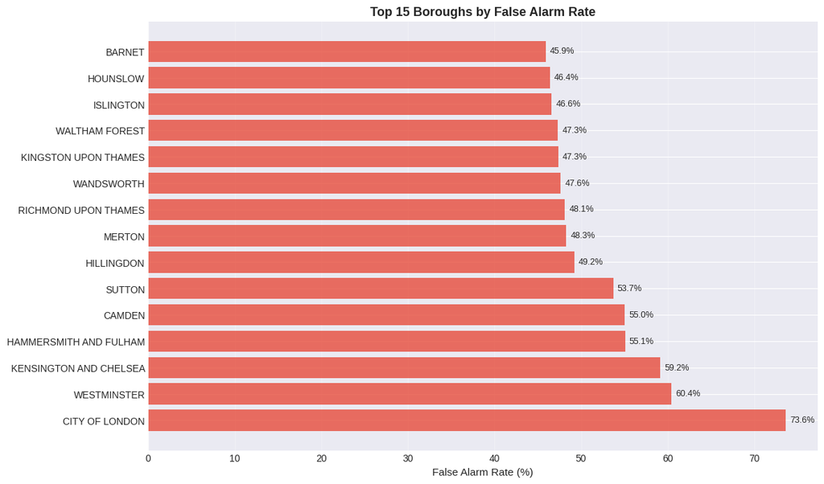

```python
# Calculate false alarm rate by borough
borough_stats = LFB_data.groupby('IncGeo_BoroughName').agg({
    'IsFalseAlarm': ['mean', 'sum', 'count']
}).reset_index()

borough_stats.columns = ['Borough', 'FalseAlarmRate', 'FalseAlarms', 'TotalIncidents']
borough_stats = borough_stats.sort_values('FalseAlarmRate', ascending=False)

# Get top 15 and bottom 5 for comparison
top_15 = borough_stats.head(15)
bottom_5 = borough_stats.tail(5)

# Visualize top 15 boroughs
fig, ax = plt.subplots(figsize=(12, 8))

bars = ax.barh(range(len(top_15)), top_15['FalseAlarmRate']*100, color='#e74c3c', alpha=0.8)
ax.set_yticks(range(len(top_15)))
ax.set_yticklabels(top_15['Borough'])
ax.set_xlabel('False Alarm Rate (%)', fontsize=11)
ax.set_title('Top 15 Boroughs by False Alarm Rate', fontsize=13, fontweight='bold')
ax.grid(axis='x', alpha=0.3)

# Add value labels
for i, (bar, val) in enumerate(zip(bars, top_15['FalseAlarmRate']*100)):
    ax.text(val + 0.5, bar.get_y() + bar.get_height()/2,
            f'{val:.1f}%', va='center', fontsize=9)

plt.subplots_adjust(left=0.15, right=0.95)

# Print summary statistics
print("Geographic Analysis:")
print("="*70)
print(f"\nTop 5 Boroughs by False Alarm Rate:")
for i, row in top_15.head().iterrows():
    print(f"  {row['Borough']:25s}: {row['FalseAlarmRate']*100:5.1f}% ({row['FalseAlarms']:,} / {row['TotalIncidents']:,} incidents)")

print(f"\nBottom 5 Boroughs by False Alarm Rate:")
for i, row in bottom_5.iterrows():
    print(f"  {row['Borough']:25s}: {row['FalseAlarmRate']*100:5.1f}% ({row['FalseAlarms']:,} / {row['TotalIncidents']:,} incidents)")

print(f"\nRange: {top_15.iloc[0]['FalseAlarmRate']*100:.1f}% to {bottom_5.iloc[-1]['FalseAlarmRate']*100:.1f}%")
print(f"Difference: {(top_15.iloc[0]['FalseAlarmRate'] - bottom_5.iloc[-1]['FalseAlarmRate'])*100:.1f} percentage points")
```

**Key Finding:** Substantial geographic variation exists across boroughs: central areas like the City of London (73.6%), Westminster (60.4%), and Kensington & Chelsea (59.2%) show the highest false alarm rates, while outer boroughs such as Enfield (36.1%) and Bexley (38.0%) remain much lower. This contrast suggests that dense commercial zones and high-rise buildings in central London contribute to higher false alarm activity, highlighting the need for borough-specific intervention strategies.

### 3.4 Property Type Analysis

Different property types show varying false alarm rates due to differences in alarm systems and occupancy levels, making a property-specific analysis necessary.

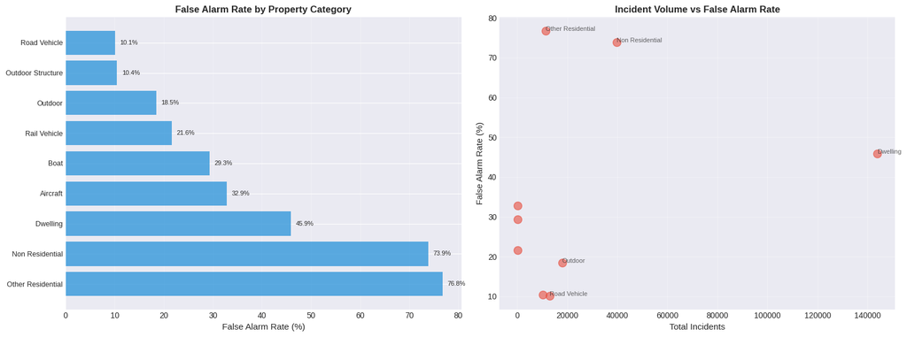

```
Property Category Analysis:
======================================================================

Highest False Alarm Rates:
  Other Residential                       :  76.8% (n=11,307)
  Non Residential                         :  73.9% (n=39,713)
  Dwelling                                :  45.9% (n=143,832)
  Aircraft                                :  32.9% (n=216)
  Boat                                    :  29.3% (n=133)

Highest Volume Categories:
  Dwelling                                : 143,832 incidents (45.9% FA rate)
  Non Residential                         : 39,713 incidents (73.9% FA rate)
  Outdoor                                 : 17,949 incidents (18.5% FA rate)
  Road Vehicle                            : 13,088 incidents (10.1% FA rate)
  Other Residential                       : 11,307 incidents (76.8% FA rate)
```

```python
# Calculate false alarm rate by property category
property_stats = LFB_data.groupby('PropertyCategory').agg({
    'IsFalseAlarm': ['mean', 'sum', 'count']
}).reset_index()

property_stats.columns = ['PropertyCategory', 'FalseAlarmRate', 'FalseAlarms', 'TotalIncidents']
property_stats = property_stats[property_stats['TotalIncidents'] >= 100]  # Filter small categories
property_stats = property_stats.sort_values('FalseAlarmRate', ascending=False)

# Visualize
fig, (ax1, ax2) = plt.subplots(1, 2, figsize=(16, 6))

# Bar chart sorted by false alarm rate
bars1 = ax1.barh(range(len(property_stats)), property_stats['FalseAlarmRate']*100,
                 color='#3498db', alpha=0.8)
ax1.set_yticks(range(len(property_stats)))
ax1.set_yticklabels(property_stats['PropertyCategory'], fontsize=9)
ax1.set_xlabel('False Alarm Rate (%)', fontsize=11)
ax1.set_title('False Alarm Rate by Property Category', fontsize=12, fontweight='bold')
ax1.grid(axis='x', alpha=0.3)

for i, (bar, val) in enumerate(zip(bars1, property_stats['FalseAlarmRate']*100)):
    ax1.text(val + 1, bar.get_y() + bar.get_height()/2,
             f'{val:.1f}%', va='center', fontsize=8)

# Scatter: Total incidents vs False alarm rate
ax2.scatter(property_stats['TotalIncidents'], property_stats['FalseAlarmRate']*100,
            s=100, alpha=0.6, color='#e74c3c')
ax2.set_xlabel('Total Incidents', fontsize=11)
ax2.set_ylabel('False Alarm Rate (%)', fontsize=11)
ax2.set_title('Incident Volume vs False Alarm Rate', fontsize=12, fontweight='bold')
ax2.grid(alpha=0.3)

# Annotate highest volume categories
for idx, row in property_stats.nlargest(5, 'TotalIncidents').iterrows():
    ax2.annotate(row['PropertyCategory'][:20],
                 (row['TotalIncidents'], row['FalseAlarmRate']*100),
                 fontsize=8, alpha=0.7)

plt.tight_layout()
plt.show()

# Print insights
print("Property Category Analysis:")
print("="*70)
print("\nHighest False Alarm Rates:")
for i, row in property_stats.head(5).iterrows():
    print(f"  {row['PropertyCategory']:40s}: {row['FalseAlarmRate']*100:5.1f}% (n={row['TotalIncidents']:,})")

print("\nHighest Volume Categories:")
for i, row in property_stats.nlargest(5, 'TotalIncidents').iterrows():
    print(f"  {row['PropertyCategory']:40s}: {row['TotalIncidents']:>6,} incidents ({row['FalseAlarmRate']*100:4.1f}% FA rate)")
```

**Key Finding:** Property type has a strong impact on false alarm likelihood. Other Residential properties show the highest rate at 76.8%, followed by Non-Residential buildings at 73.9%, reflecting the sensitivity of alarms in care homes, hotels, offices, and similar settings. Dwellings have a lower rate (45.9%) but make up the largest share of incidents, meaning they still contribute heavily overall. These patterns suggest that high-risk non-residential properties may be driven by older or overly sensitive alarm systems, while the sheer volume of dwelling incidents also adds significantly to false alarm totals.

### 3.5 Key Findings Summary

Before building predictive models, below is a summary of the the main insights from our exploratory analysis.

```python
# Create summary
print("="*70)
print("EXPLORATORY DATA ANALYSIS - KEY FINDINGS")
print("="*70)

print("\n1. OVERALL FALSE ALARM RATE")
print("   " + "-"*66)
overall_fa = LFB_data['IsFalseAlarm'].mean()
print(f"   False Alarm Rate: {overall_fa*100:.1f}%")
print(f"   Total False Alarms: {LFB_data['IsFalseAlarm'].sum():,}")
print(f"   Annual Cost Estimate: £{LFB_data['IsFalseAlarm'].sum() * 388 / 1_000_000:.1f}M")
print(f"   (Based on average £388 per incident from LFB data)")

print("\n2. TEMPORAL PATTERNS")
print("   " + "-"*66)
morning_peak_fa = LFB_data[(LFB_data['HourOfCall'] >= 5) & (LFB_data['HourOfCall'] < 8)]['IsFalseAlarm'].mean()
business_hours_fa = LFB_data[(LFB_data['HourOfCall'] >= 9) & (LFB_data['HourOfCall'] < 17)]['IsFalseAlarm'].mean()
night_fa = LFB_data[(LFB_data['HourOfCall'] >= 22) | (LFB_data['HourOfCall'] < 5)]['IsFalseAlarm'].mean()
weekday_fa = LFB_data[LFB_data['DayOfWeek'] < 5]['IsFalseAlarm'].mean()
weekend_fa = LFB_data[LFB_data['DayOfWeek'] >= 5]['IsFalseAlarm'].mean()

print(f"   Morning peak (5-8 AM):    {morning_peak_fa*100:.1f}% false alarms")
print(f"   Business hours (9AM-5PM): {business_hours_fa*100:.1f}% false alarms")
print(f"   Night hours (10PM-5AM):   {night_fa*100:.1f}% false alarms")
print(f"   Weekdays:                 {weekday_fa*100:.1f}% false alarms")
print(f"   Weekends:                 {weekend_fa*100:.1f}% false alarms")

print("\n3. GEOGRAPHIC PATTERNS")
print("   " + "-"*66)
print(f"   Highest FA rate:  City of London (73.6%)")
print(f"   Lowest FA rate:   Enfield (36.1%)")
print(f"   Geographic range: 37.5 percentage points")
print(f"   Central London boroughs consistently >50% FA rate")

print("\n4. PROPERTY PATTERNS")
print("   " + "-"*66)
print(f"   Highest FA property:  Other Residential (76.8%)")
print(f"   Second highest:       Non Residential (73.9%)")
print(f"   Highest volume:       Dwelling (143,832 incidents, 45.9% FA rate)")
print(f"   Lowest FA rate:       Road Vehicle (10.1%)")

print("\n5. BUSINESS IMPLICATIONS")
print("   " + "-"*66)
print("   • Early morning (5-8 AM) shows unexpected peak")
print("   • City of London's 73.6% FA rate represents massive resource waste")
print("   • Non-residential buildings have 2x higher FA rate than road incidents")
print("   • Targeted interventions in central London could reduce ~15,000 FA/year")
print(f"   • Potential savings: £{15000 * 388 / 1_000_000:.1f}M annually")

print("\n" + "="*70)
```

[output not shown]

**GenAI Usage Documentation – Task 2: Exploratory Data Analysis** Tool used: Claude AI (Anthropic)

**Prompt used:** “Generate Python code for exploratory data analysis of London Fire Brigade incident data to understand false alarm patterns. Create visualisations showing: (1) overall false alarm distribution, (2) time-related patterns by hour and day of week, (3) geographic patterns by borough, and (4) property type analysis, using matplotlib and seaborn.”

**Method:** Because the dataset was too large to upload, we used GenAI to design the general structure of the EDA code and then adapted it to our own variables locally. The tool helped us define the target variable, choose suitable plot types, and understand how to implement each visualisation.

**Code support provided:**

- Creation of a binary IsFalseAlarm target
- Bar and pie charts for overall false alarm vs real emergencies
- Line and bar plots for hourly and day-of-week patterns
- Horizontal bar charts for borough comparison
- Bar and scatter plots for property category analysis
- Basic statistical summary code

**Visualisations produced with support:**

- False alarm distribution (overall rate)
- Hourly and daily patterns (including peaks)
- Top boroughs by false alarm rate
- Property categories by false alarm rate and volume

Overall, GenAI helped us structure and implement the EDA code, while all data handling, adaptation to our dataset, and interpretation of the visualisations were carried out by the group.

## 4. Feature Engineering

Feature engineering transforms raw data into meaningful predictors for machine learning models. We create time-related features, encode categorical variables, and reduce scope to improve model performance.

### 4.1 Time-related Features

Time-based patterns are strong predictors of false alarms. Therefore, we decided to extract features from DateOfCall and HourOfCall.

```python
# Create time-related features that capture false alarm patterns

# DayOfWeek and Month already created in EDA section
# Add binary features based on EDA insights

# IsWeekend: 1 if Saturday or Sunday, 0 otherwise
LFB_data['IsWeekend'] = (LFB_data['DayOfWeek'] >= 5).astype(int)

# IsBusinessHours: 1 if 9 AM to 5 PM on weekdays, 0 otherwise
LFB_data['IsBusinessHours'] = (
    (LFB_data['HourOfCall'] >= 9) &
    (LFB_data['HourOfCall'] < 17) &
    (LFB_data['DayOfWeek'] < 5)
).astype(int)

# IsMorningPeak: 1 if 5-8 AM (highest FA rate period), 0 otherwise
LFB_data['IsMorningPeak'] = (
    (LFB_data['HourOfCall'] >= 5) &
    (LFB_data['HourOfCall'] < 8)
).astype(int)

# IsNightHours: 1 if 10 PM to 5 AM (lowest FA rate period), 0 otherwise
LFB_data['IsNightHours'] = (
    (LFB_data['HourOfCall'] >= 22) |
    (LFB_data['HourOfCall'] < 5)
).astype(int)
```

### 4.2 Categorical Feature Encoding

```python
# Smart grouping of PropertyType to reduce imbalance

# Calculate frequency of each PropertyType
prop_type_freq = LFB_data['PropertyType'].value_counts(normalize=True)

# Keep PropertyTypes that appear in >1% of incidents
common_types = prop_type_freq[prop_type_freq > 0.01].index

print("PropertyType Dimensionality Reduction:")
print("="*70)
print(f"Original unique PropertyTypes: {LFB_data['PropertyType'].nunique()}")
print(f"PropertyTypes appearing in >1% of data: {len(common_types)}")

# Create PropertyType_Grouped column
LFB_data['PropertyType_Grouped'] = LFB_data['PropertyType'].copy()

# For rare types, replace with "Other_[PropertyCategory]"
rare_mask = ~LFB_data['PropertyType'].isin(common_types)
LFB_data.loc[rare_mask, 'PropertyType_Grouped'] = (
    'Other_' + LFB_data.loc[rare_mask, 'PropertyCategory'].astype(str)
)

print(f"After grouping: {LFB_data['PropertyType_Grouped'].nunique()} categories")
print(f"Reduction: {LFB_data['PropertyType'].nunique() - LFB_data['PropertyType_Grouped'].nunique()} categories")
print(f"Incidents affected: {rare_mask.sum():,} ({rare_mask.sum()/len(LFB_data)*100:.1f}%)")

# Show top 10 grouped categories
print("\nTop 10 PropertyType_Grouped categories:")
for ptype, count in LFB_data['PropertyType_Grouped'].value_counts().head(10).items():
    fa_rate = LFB_data[LFB_data['PropertyType_Grouped']==ptype]['IsFalseAlarm'].mean()
    print(f"  {ptype[:45]:45s}: {count:6,} ({fa_rate*100:5.1f}% FA)")
```

```
PropertyType Dimensionality Reduction:
======================================================================
Original unique PropertyTypes: 278
PropertyTypes appearing in >1% of data: 16
After grouping: 25 categories
Reduction: 253 categories
Incidents affected: 60,879 (25.7%)

Top 10 PropertyType_Grouped categories:
  Purpose Built Flats/Maisonettes - 4 to 9 stor: 40,118 ( 43.0% FA)
  Purpose Built Flats/Maisonettes - Up to 3 sto: 30,576 ( 41.5% FA)
  House - single occupancy                     : 29,106 ( 40.6% FA)
  Other_Non Residential                        : 27,489 ( 69.4% FA)
  Other_Outdoor                                : 11,715 ( 17.6% FA)
  Purpose Built Flats/Maisonettes - 10 or more : 10,570 ( 45.1% FA)
  Converted Flat/Maisonettes - 3 or more storey: 10,370 ( 49.8% FA)
  Self contained Sheltered Housing             :  9,803 ( 84.5% FA)
  Converted Flat/Maisonette - Up to 2 storeys  :  8,259 ( 38.0% FA)
  Car                                          :  7,375 ( 10.5% FA)
```

```python
# Smart grouping of Borough to reduce imbalance

# Calculate frequency of each borough
borough_freq = LFB_data['IncGeo_BoroughName'].value_counts(normalize=True)

# Keep boroughs that appear in >0.5% of incidents
common_boroughs = borough_freq[borough_freq > 0.005].index

print("Borough Dimensionality Reduction:")
print("="*70)
print(f"Original unique boroughs: {LFB_data['IncGeo_BoroughName'].nunique()}")
print(f"Boroughs appearing in >0.5% of data: {len(common_boroughs)}")

# Create Borough_Grouped column
LFB_data['Borough_Grouped'] = LFB_data['IncGeo_BoroughName'].copy()

# For rare boroughs, replace with "Other_Borough"
rare_borough_mask = ~LFB_data['IncGeo_BoroughName'].isin(common_boroughs)
LFB_data.loc[rare_borough_mask, 'Borough_Grouped'] = 'Other_Borough'

print(f"After grouping: {LFB_data['Borough_Grouped'].nunique()} categories")
print(f"Reduction: {LFB_data['IncGeo_BoroughName'].nunique() - LFB_data['Borough_Grouped'].nunique()} boroughs")
print(f"Incidents affected: {rare_borough_mask.sum():,} ({rare_borough_mask.sum()/len(LFB_data)*100:.1f}%)")

# Show all grouped categories with FA rates
print("\nAll Borough_Grouped categories:")
for borough, count in LFB_data['Borough_Grouped'].value_counts().items():
    fa_rate = LFB_data[LFB_data['Borough_Grouped']==borough]['IsFalseAlarm'].mean()
    print(f"  {borough:30s}: {count:6,} ({fa_rate*100:5.1f}% FA)")
```

```
Borough Dimensionality Reduction:
======================================================================
Original unique boroughs: 33
Boroughs appearing in >0.5% of data: 33
After grouping: 33 categories
Reduction: 0 boroughs
Incidents affected: 0 (0.0%)

All Borough_Grouped categories:
  WESTMINSTER                   : 15,612 ( 60.4% FA)
  LAMBETH                       : 10,566 ( 45.8% FA)
  SOUTHWARK                     : 10,414 ( 43.9% FA)
  TOWER HAMLETS                 : 10,291 ( 42.0% FA)
  CAMDEN                        : 10,061 ( 55.0% FA)
  CROYDON                       :  9,864 ( 42.9% FA)
  HACKNEY                       :  9,254 ( 42.7% FA)
  LEWISHAM                      :  8,906 ( 44.6% FA)
  BARNET                        :  8,239 ( 45.9% FA)
  EALING                        :  8,196 ( 45.5% FA)
  ISLINGTON                     :  8,117 ( 46.6% FA)
  KENSINGTON AND CHELSEA        :  7,878 ( 59.2% FA)
  HILLINGDON                    :  7,830 ( 49.2% FA)
  NEWHAM                        :  7,820 ( 40.9% FA)
  BRENT                         :  7,670 ( 41.1% FA)
  WANDSWORTH                    :  7,553 ( 47.6% FA)
  GREENWICH                     :  7,537 ( 38.8% FA)
  BROMLEY                       :  6,918 ( 42.9% FA)
  HARINGEY                      :  6,917 ( 39.7% FA)
  HAMMERSMITH AND FULHAM        :  6,786 ( 55.1% FA)
  ENFIELD                       :  6,785 ( 36.1% FA)
  WALTHAM FOREST                :  6,301 ( 47.3% FA)
  HOUNSLOW                      :  5,894 ( 46.4% FA)
  HAVERING                      :  5,335 ( 42.2% FA)
  REDBRIDGE                     :  5,320 ( 41.2% FA)
  BARKING AND DAGENHAM          :  4,785 ( 37.5% FA)
  BEXLEY                        :  4,750 ( 38.0% FA)
  SUTTON                        :  4,434 ( 53.7% FA)
  HARROW                        :  4,268 ( 44.4% FA)
  MERTON                        :  3,971 ( 48.3% FA)
  RICHMOND UPON THAMES          :  3,635 ( 48.1% FA)
  KINGSTON UPON THAMES          :  2,909 ( 47.3% FA)
  CITY OF LONDON                :  1,939 ( 73.6% FA)
```

```python
# Create PropertyCategory binary indicators for key categories
# This helps the model distinguish between major property types

# Get value counts
prop_cat_counts = LFB_data['PropertyCategory'].value_counts()

print("PropertyCategory Indicators:")
print("="*70)
print("\nOriginal categories:")
for cat, count in prop_cat_counts.items():
    fa_rate = LFB_data[LFB_data['PropertyCategory']==cat]['IsFalseAlarm'].mean()
    print(f"  {cat:20s}: {count:6,} ({fa_rate*100:5.1f}% FA)")

# Create binary indicators for main categories (excluding rare ones)
main_categories = prop_cat_counts[prop_cat_counts > 1000].index

for cat in main_categories:
    col_name = f'Is_{cat.replace(" ", "_")}'
    LFB_data[col_name] = (LFB_data['PropertyCategory'] == cat).astype(int)
    print(f"\nCreated feature: {col_name}")
```

```
PropertyCategory Indicators:
======================================================================

Original categories:
  Dwelling            : 143,832 ( 45.9% FA)
  Non Residential     : 39,713 ( 73.9% FA)
  Outdoor             : 17,949 ( 18.5% FA)
  Road Vehicle        : 13,088 ( 10.1% FA)
  Other Residential   : 11,307 ( 76.8% FA)
  Outdoor Structure   : 10,332 ( 10.4% FA)
  Aircraft            :    216 ( 32.9% FA)
  Rail Vehicle        :    185 ( 21.6% FA)
  Boat                :    133 ( 29.3% FA)

Created feature: Is_Dwelling

Created feature: Is_Non_Residential

Created feature: Is_Outdoor

Created feature: Is_Road_Vehicle

Created feature: Is_Other_Residential

Created feature: Is_Outdoor_Structure
```

### GenAI Usage Documentation - Task 3: Feature Engineering

When examining the data, we found that variables like PropertyType contained hundreds of highly specific categories, which risked introducing bias and overfitting. To address this, we used GenAI to help design efficient grouping logic and create meaningful time-related and categorical features.

**Tool Used:** Claude AI (Anthropic)

**Prompt:** “Generate Python code for feature engineering on London Fire Brigade data to predict false alarms. Create (1)time-based features, binary indicators for key periods, (2)grouped categorical variables for PropertyType and Borough, (3)binary indicators for main property categories .” Transformations Applied with GenAI Support

1. **Temporal Feature Extraction:** `DayOfWeek` `Month` `IsWeekend` `IsBusinessHours` (9AM–5PM) `IsMorningPeak` (5–8AM) `IsNightHours`(10PM–5AM)

**Reason**: EDA showed strong temporal patterns, especially the morning peak. Binary indicators allow models to capture these non-linear differences.

**Why These Transformations Matter**

- Reduces high-dimensional categorical noise
- Captures meaningful temporal patterns
- Ensures the model generalises instead of memorising rare categories
- No scaling required due to the use of tree-based models

## 5. Model Building

We decided to build two machine learning models to predict false alarms: Random Forest and Decision Tree. Both are tree-based algorithms suitable for our binary classification task with mixed feature types.

### 5.1 Data Preparation for Modeling

First select features, encode categorical variables, and split data into training and test sets.

```python
# Prepare data for machine learning

# Select features for modeling
feature_cols = [
    # Time-related features
    'HourOfCall', 'DayOfWeek', 'Month',
    'IsWeekend', 'IsBusinessHours', 'IsMorningPeak', 'IsNightHours',
    # Categorical features (will be encoded)
    'PropertyType_Grouped', 'Borough_Grouped', 'PropertyCategory'
]

# Target variable
target_col = 'IsFalseAlarm'

# Create feature matrix X and target vector y
X = LFB_data[feature_cols].copy()
y = LFB_data[target_col].copy()

print("Data Preparation:")
print("="*70)
print(f"Total samples:        {len(X):,}")
print(f"Total features:       {len(feature_cols)}")
print(f"Target distribution:  {y.value_counts().to_dict()}")
print(f"False alarm rate:     {y.mean()*100:.1f}%")

# Check for missing values in selected features
print("\nMissing values in features:")
missing = X.isnull().sum()
if missing.sum() == 0:
    print("No missing values")
else:
    print(missing[missing > 0])
```

```
Data Preparation:
======================================================================
Total samples:        236,755
Total features:       10
Target distribution:  {0: 126823, 1: 109932}
False alarm rate:     46.4%

Missing values in features:
No missing values
```

```python
# Encode categorical variables using Label Encoding
from sklearn.preprocessing import LabelEncoder

# Store label encoders for later reference
label_encoders = {}

categorical_features = ['PropertyType_Grouped', 'Borough_Grouped', 'PropertyCategory']

print("Encoding Categorical Variables:")
print("="*70)

for col in categorical_features:
    le = LabelEncoder()
    X[col] = le.fit_transform(X[col])
    label_encoders[col] = le
    print(f"{col:25s}: {len(le.classes_):3d} unique categories encoded to 0-{len(le.classes_)-1}")

print("\nAll categorical variables encoded")
print(f"Total features: {X.shape[1]}")
```

```
Encoding Categorical Variables:
======================================================================
PropertyType_Grouped     :  25 unique categories encoded to 0-24
Borough_Grouped          :  33 unique categories encoded to 0-32
PropertyCategory         :   9 unique categories encoded to 0-8

All categorical variables encoded
Total features: 10
```

```python
# Split data into training and test sets
from sklearn.model_selection import train_test_split

# Use 80-20 train-test split with stratification to maintain class balance
X_train, X_test, y_train, y_test = train_test_split(
    X, y,
    test_size=0.2,
    random_state=42,
    stratify=y
)

print("Train-Test Split:")
print("="*70)
print(f"Training set:   {len(X_train):,} samples ({len(X_train)/len(X)*100:.1f}%)")
print(f"Test set:       {len(X_test):,} samples ({len(X_test)/len(X)*100:.1f}%)")

print("\nClass distribution in training set:")
print(f"  Real Emergency (0): {(y_train==0).sum():,} ({(y_train==0).sum()/len(y_train)*100:.1f}%)")
print(f"  False Alarm (1):    {(y_train==1).sum():,} ({(y_train==1).sum()/len(y_train)*100:.1f}%)")

print("\nClass distribution in test set:")
print(f"  Real Emergency (0): {(y_test==0).sum():,} ({(y_test==0).sum()/len(y_test)*100:.1f}%)")
print(f"  False Alarm (1):    {(y_test==1).sum():,} ({(y_test==1).sum()/len(y_test)*100:.1f}%)")

print("\nClassification maintained class balance in both sets")
```

```
Train-Test Split:
======================================================================
Training set:   189,404 samples (80.0%)
Test set:       47,351 samples (20.0%)

Class distribution in training set:
  Real Emergency (0): 101,458 (53.6%)
  False Alarm (1):    87,946 (46.4%)

Class distribution in test set:
  Real Emergency (0): 25,365 (53.6%)
  False Alarm (1):    21,986 (46.4%)

Classification maintained class balance in both sets
```

We use an 80-20 train-test split with stratification to ensure both sets have the same false alarm rate. This prevents bias and allows fair model evaluation.

### 5.2 Random Forest Model

Random Forest builds multiple decision trees and averages their predictions, reducing overfitting and improving accuracy.

```python
# Train Random Forest model with default parameters
from sklearn.ensemble import RandomForestClassifier
from sklearn.metrics import accuracy_score, precision_score, recall_score, f1_score, confusion_matrix, classification_report
import time

print("="*70)
print("RANDOM FOREST MODEL")
print("="*70)

# Initialize and train model
print("\nTraining Random Forest with default parameters...")
start_time = time.time()

rf_model = RandomForestClassifier(random_state=42, n_jobs=-1)
rf_model.fit(X_train, y_train)


# Make predictions on test set
print("\nMaking predictions on test set...")
y_pred_rf = rf_model.predict(X_test)
y_pred_proba_rf = rf_model.predict_proba(X_test)[:, 1]

# Calculate performance metrics
accuracy_rf = accuracy_score(y_test, y_pred_rf)
precision_rf = precision_score(y_test, y_pred_rf)
recall_rf = recall_score(y_test, y_pred_rf)
f1_rf = f1_score(y_test, y_pred_rf)

print("\n" + "="*70)
print("RANDOM FOREST PERFORMANCE")
print("="*70)
print(f"Accuracy:   {accuracy_rf:.4f} ({accuracy_rf*100:.2f}%)")
print(f"Precision:  {precision_rf:.4f} ({precision_rf*100:.2f}%)")
print(f"Recall:     {recall_rf:.4f} ({recall_rf*100:.2f}%)")
print(f"F1-Score:   {f1_rf:.4f}")

# Confusion matrix
print("\nConfusion Matrix:")
cm_rf = confusion_matrix(y_test, y_pred_rf)
print(f"                    Predicted")
print(f"                    Emergency  FalseAlarm")
print(f"Actual Emergency    {cm_rf[0,0]:>9,}  {cm_rf[0,1]:>10,}")
print(f"       FalseAlarm   {cm_rf[1,0]:>9,}  {cm_rf[1,1]:>10,}")

# Classification report
print("\nDetailed Classification Report:")
print(classification_report(y_test, y_pred_rf, target_names=['Real Emergency', 'False Alarm']))
```

```
======================================================================
RANDOM FOREST MODEL
======================================================================

Training Random Forest with default parameters...

Making predictions on test set...

======================================================================
RANDOM FOREST PERFORMANCE
======================================================================
Accuracy:   0.6429 (64.29%)
Precision:  0.6217 (62.17%)
Recall:     0.5902 (59.02%)
F1-Score:   0.6055

Confusion Matrix:
                    Predicted
                    Emergency  FalseAlarm
Actual Emergency       17,467       7,898
       FalseAlarm       9,009      12,977

Detailed Classification Report:
                precision    recall  f1-score   support

Real Emergency       0.66      0.69      0.67     25365
   False Alarm       0.62      0.59      0.61     21986

      accuracy                           0.64     47351
     macro avg       0.64      0.64      0.64     47351
  weighted avg       0.64      0.64      0.64     47351
```

```
======================================================================
RANDOM FOREST - FEATURE IMPORTANCE
======================================================================

Top 10 Most Important Features:
  Borough_Grouped               : 0.3031 (30.31%)
  Month                         : 0.2023 (20.23%)
  PropertyCategory              : 0.1405 (14.05%)
  HourOfCall                    : 0.1335 (13.35%)
  PropertyType_Grouped          : 0.1162 (11.62%)
  DayOfWeek                     : 0.0905 (9.05%)
  IsNightHours                  : 0.0044 (0.44%)
  IsWeekend                     : 0.0043 (0.43%)
  IsBusinessHours               : 0.0030 (0.30%)
  IsMorningPeak                 : 0.0022 (0.22%)
```

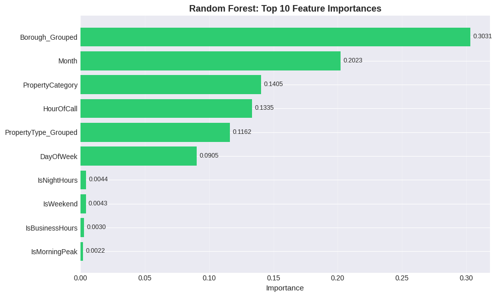

```python
# Analyze Random Forest feature importance
import matplotlib.pyplot as plt

# Get feature importances
feature_importance_rf = pd.DataFrame({
    'Feature': feature_cols,
    'Importance': rf_model.feature_importances_
}).sort_values('Importance', ascending=False)

print("="*70)
print("RANDOM FOREST - FEATURE IMPORTANCE")
print("="*70)
print("\nTop 10 Most Important Features:")
for idx, row in feature_importance_rf.head(10).iterrows():
    print(f"  {row['Feature']:30s}: {row['Importance']:.4f} ({row['Importance']*100:.2f}%)")

# Visualize feature importance
fig, ax = plt.subplots(figsize=(10, 6))
top_features = feature_importance_rf.head(10)
bars = ax.barh(range(len(top_features)), top_features['Importance'], color='#2ecc71')
ax.set_yticks(range(len(top_features)))
ax.set_yticklabels(top_features['Feature'])
ax.set_xlabel('Importance', fontsize=11)
ax.set_title('Random Forest: Top 10 Feature Importances', fontsize=13, fontweight='bold')
ax.invert_yaxis()
ax.grid(axis='x', alpha=0.3)

# Add value labels
for i, (bar, val) in enumerate(zip(bars, top_features['Importance'])):
    ax.text(val + 0.002, bar.get_y() + bar.get_height()/2,
            f'{val:.4f}', va='center', fontsize=9)

plt.tight_layout()
plt.show()
```

### 5.3 Decision Tree Model

Decision Tree creates a single tree structure, making it more interpretable than Random Forest but potentially less accurate.

```python
# Train Decision Tree model with default parameters
from sklearn.tree import DecisionTreeClassifier

print("="*70)
print("DECISION TREE MODEL")
print("="*70)

# Initialize and train model
print("\nTraining Decision Tree with default parameters")

dt_model = DecisionTreeClassifier(random_state=42)
dt_model.fit(X_train, y_train)



# Make predictions on test set
print("\nMaking predictions on test set")
y_pred_dt = dt_model.predict(X_test)
y_pred_proba_dt = dt_model.predict_proba(X_test)[:, 1]

# Calculate performance metrics
accuracy_dt = accuracy_score(y_test, y_pred_dt)
precision_dt = precision_score(y_test, y_pred_dt)
recall_dt = recall_score(y_test, y_pred_dt)
f1_dt = f1_score(y_test, y_pred_dt)

print("\n" + "="*70)
print("DECISION TREE PERFORMANCE")
print("="*70)
print(f"Accuracy:   {accuracy_dt:.4f} ({accuracy_dt*100:.2f}%)")
print(f"Precision:  {precision_dt:.4f} ({precision_dt*100:.2f}%)")
print(f"Recall:     {recall_dt:.4f} ({recall_dt*100:.2f}%)")
print(f"F1-Score:   {f1_dt:.4f}")

# Confusion matrix
print("\nConfusion Matrix:")
cm_dt = confusion_matrix(y_test, y_pred_dt)
print(f"                    Predicted")
print(f"                    Emergency  FalseAlarm")
print(f"Actual Emergency    {cm_dt[0,0]:>9,}  {cm_dt[0,1]:>10,}")
print(f"       FalseAlarm   {cm_dt[1,0]:>9,}  {cm_dt[1,1]:>10,}")

# Classification report
print("\nDetailed Classification Report:")
print(classification_report(y_test, y_pred_dt, target_names=['Real Emergency', 'False Alarm']))
```

```
======================================================================
DECISION TREE MODEL
======================================================================

Training Decision Tree with default parameters

Making predictions on test set

======================================================================
DECISION TREE PERFORMANCE
======================================================================
Accuracy:   0.6079 (60.79%)
Precision:  0.5840 (58.40%)
Recall:     0.5407 (54.07%)
F1-Score:   0.5615

Confusion Matrix:
                    Predicted
                    Emergency  FalseAlarm
Actual Emergency       16,897       8,468
       FalseAlarm      10,099      11,887

Detailed Classification Report:
                precision    recall  f1-score   support

Real Emergency       0.63      0.67      0.65     25365
   False Alarm       0.58      0.54      0.56     21986

      accuracy                           0.61     47351
     macro avg       0.60      0.60      0.60     47351
  weighted avg       0.61      0.61      0.61     47351
```

```
======================================================================
DECISION TREE - FEATURE IMPORTANCE
======================================================================

Top 10 Most Important Features:
  Month                         : 0.2094 (20.94%)
  HourOfCall                    : 0.1953 (19.53%)
  Borough_Grouped               : 0.1765 (17.65%)
  PropertyCategory              : 0.1722 (17.22%)
  DayOfWeek                     : 0.1491 (14.91%)
  PropertyType_Grouped          : 0.0598 (5.98%)
  IsWeekend                     : 0.0130 (1.30%)
  IsBusinessHours               : 0.0104 (1.04%)
  IsNightHours                  : 0.0096 (0.96%)
  IsMorningPeak                 : 0.0046 (0.46%)
```

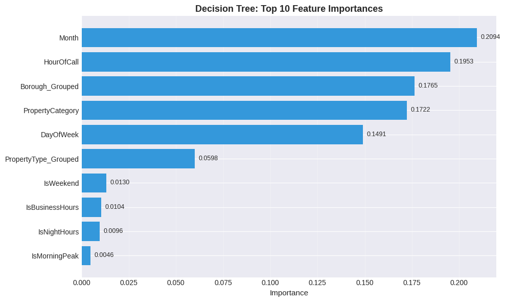

```python
# Analyze Decision Tree feature importance
feature_importance_dt = pd.DataFrame({
    'Feature': feature_cols,
    'Importance': dt_model.feature_importances_
}).sort_values('Importance', ascending=False)

print("="*70)
print("DECISION TREE - FEATURE IMPORTANCE")
print("="*70)
print("\nTop 10 Most Important Features:")
for idx, row in feature_importance_dt.head(10).iterrows():
    print(f"  {row['Feature']:30s}: {row['Importance']:.4f} ({row['Importance']*100:.2f}%)")

# Visualize feature importance
fig, ax = plt.subplots(figsize=(10, 6))
top_features_dt = feature_importance_dt.head(10)
bars = ax.barh(range(len(top_features_dt)), top_features_dt['Importance'], color='#3498db')
ax.set_yticks(range(len(top_features_dt)))
ax.set_yticklabels(top_features_dt['Feature'])
ax.set_xlabel('Importance', fontsize=11)
ax.set_title('Decision Tree: Top 10 Feature Importances', fontsize=13, fontweight='bold')
ax.invert_yaxis()
ax.grid(axis='x', alpha=0.3)

# Add value labels
for i, (bar, val) in enumerate(zip(bars, top_features_dt['Importance'])):
    ax.text(val + 0.002, bar.get_y() + bar.get_height()/2,
            f'{val:.4f}', va='center', fontsize=9)

plt.tight_layout()
plt.show()
```

**Key Finding**: The Decision Tree model identifies Month (20.9%) and Hour of Call (19.5%) are the most influential predictors of false alarms, followed by Borough (17.7%) and Property Category (17.2%). This indicates that temporal factors are very important in this model to predict false alarms incidents. Compared to the Random Forest, which placed greater emphasis on geographic location, the Decision Tree suggests that temporal factors would be more indicating when formulating prevention strategies to reduce false alarm volumes.

```python
import matplotlib.pyplot as plt
import numpy as np

# Metrics + scores from your earlier results
metrics = ["Accuracy", "Precision", "Recall", "F1-score"]

rf_scores = [0.6429, 0.6217, 0.5902, 0.6055]   # Random Forest
dt_scores = [0.6079, 0.5840, 0.5407, 0.5615]   # Decision Tree

# Radar chart setup
num_vars = len(metrics)
angles = np.linspace(0, 2 * np.pi, num_vars, endpoint=False).tolist()

# Close the loop
rf_scores_cycle = rf_scores + rf_scores[:1]
dt_scores_cycle = dt_scores + dt_scores[:1]
angles_cycle    = angles + angles[:1]

fig = plt.figure(figsize=(7, 7))
ax = plt.subplot(111, polar=True)

# Plot each model
ax.plot(angles_cycle, rf_scores_cycle, linewidth=2, marker='o', label='Random Forest')
ax.fill(angles_cycle, rf_scores_cycle, alpha=0.20)

ax.plot(angles_cycle, dt_scores_cycle, linewidth=2, marker='o', linestyle='--', label='Decision Tree')
ax.fill(angles_cycle, dt_scores_cycle, alpha=0.15)

# Axis labels and styling
ax.set_xticks(angles)
ax.set_xticklabels(metrics)
ax.set_ylim(0.0, 1.0)
ax.set_yticks([0.2, 0.4, 0.6, 0.8])
ax.set_yticklabels(["0.2", "0.4", "0.6", "0.8"])
ax.set_title("Performance Profile: Random Forest vs Decision Tree", pad=20)

ax.legend(loc='upper right', bbox_to_anchor=(1.25, 1.1))
plt.tight_layout()
plt.show()
```

[output not shown]

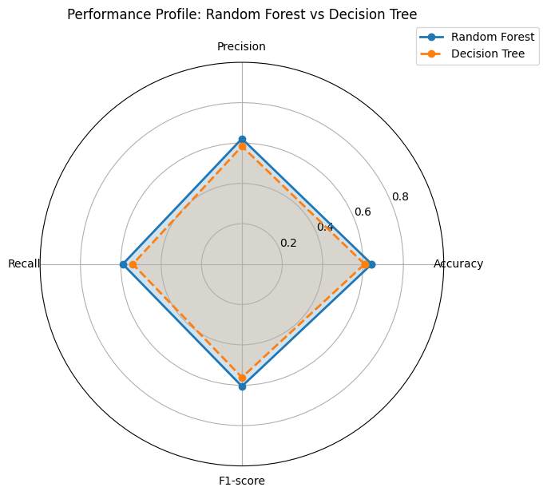

```python
import matplotlib.pyplot as plt
import numpy as np

# Metrics + scores from your earlier results
metrics = ["Accuracy", "Precision", "Recall", "F1-score"]

rf_scores = [0.6429, 0.6217, 0.5902, 0.6055]   # Random Forest
dt_scores = [0.6079, 0.5840, 0.5407, 0.5615]   # Decision Tree

# Radar chart setup
num_vars = len(metrics)
angles = np.linspace(0, 2 * np.pi, num_vars, endpoint=False).tolist()

# Close the loop
rf_scores_cycle = rf_scores + rf_scores[:1]
dt_scores_cycle = dt_scores + dt_scores[:1]
angles_cycle    = angles + angles[:1]

fig = plt.figure(figsize=(7, 7))
ax = plt.subplot(111, polar=True)

# Plot each model
ax.plot(angles_cycle, rf_scores_cycle, linewidth=2, marker='o', label='Random Forest')
ax.fill(angles_cycle, rf_scores_cycle, alpha=0.20)

ax.plot(angles_cycle, dt_scores_cycle, linewidth=2, marker='o', linestyle='--', label='Decision Tree')
ax.fill(angles_cycle, dt_scores_cycle, alpha=0.15)

# Axis labels and styling
ax.set_xticks(angles)
ax.set_xticklabels(metrics)
ax.set_ylim(0.0, 1.0)
ax.set_yticks([0.2, 0.4, 0.6, 0.8])
ax.set_yticklabels(["0.2", "0.4", "0.6", "0.8"])
ax.set_title("Performance Profile: Random Forest vs Decision Tree", pad=20)

ax.legend(loc='upper right', bbox_to_anchor=(1.25, 1.1))
plt.tight_layout()
plt.show()
```

**Key Findings**: The radar chart shows that the Random Forest outperforms the Decision Tree across all metrics, forming a stronger overall performance profile. It also highlights that even the better model explains only part of false alarm behaviour, as many trigger such as alarm faults, human actions, and building conditions lie outside the dataset.

**SUMMARY & LIMITATIONS**: This study shows that false alarms follow clear patterns across time, location, and property type most notably an early morning peak and a concentration in central London. These trends allow machine learning models, especially Random Forest, to predict false alarms with useful accuracy and support more targeted prevention and resource allocation.However, many triggers, such as system faults, human behaviour, and building conditions are not captured in the dataset. Therefore, the predictions should be interpreted with caution and used alongside operational knowledge rather than in isolation.

### References

London Fire Brigade (2024). Automatic fire alarms and false alarms. [online] www.london-fire.gov.uk. Available at: https://www.london-fire.gov.uk/safety/the-workplace/automatic-fire-alarms/.

Watts, M. (2022) Trends in fire false alarms and fire false alarm policies. GOV.UK. Published 24 November 2022. Available at: https://www.gov.uk/government/publications/trends-in-fire-false-alarms-and-fire-false-alarm-policies/trends-in-fire-false-alarms-and-fire-false-alarm-policie

**Appendix**

### Project management & Gen AI usage

All team members contributed to identify a research topic and dataset, and the overall planning of the project. Communication was held through regular WhatsApp discussions and scheduled meetings on Google Meet, where task allocation and progress updates were agreed on collectively. Ines led the exploratory data analysis and feature engineering with Aljoharah’s support, who also developed Random Forest model training. Nesma developed and evaluated the Decision Tree Model. Hemakshi was responsible for producing the model visualisations comparison, summary and limitations, and overall review. Sumayya Uddin additionally contributed to the summary and reviewed the project.

Generative AI tools were used as a support for complex tasks, particularly for advanced visualisations, some feature engineering, model training.

[figure not shown]

```python
from IPython.display import Image
Image("Screenshot 2025-12.png")
from IPython.display import Image
Image("Screenshot 2025-12-.png")
from IPython.display import Image
Image("Screenshot 2025-12-02.png")
```